# Data Transformation & Visualization in Python: numpy, pandas, matplotlib, and seaborn

### Heatmaps

Heatmaps are an area where seaborn really makes things a bit easier.

You can use 'plt.pcolormesh' to plot a grid of color in matplotlib. However, you'll have to set up all the tick-labels manually.

Here's an example plotting a heatmap with seaborn

```python
# Number of departures per hour
# Rows - day of the week
# Columns - hour of the day
# Values - avg # of flights

def day_of_week_2013(month, day):
    """
    2013 was NOT a leapyear and started on a Tuesday
    """
    days = ['Monday', 'Tuesday', 'Wednesday', 'Thursday', 'Friday', 'Saturday', 'Sunday']
    day_num = (month-1)*31 + day
    if month > 2: day_num -= 3
    if month > 4: day_num -= 1
    if month > 6: day_num -= 1
    if month > 9: day_num -= 1
    if month > 11: day_num -= 1

    return days[(day_num) % 7]

flights['Weekday'] = [day_of_week_2013(month, day) for month, day in zip(flights.month, flights.day)]

counts = flights.groupby(['Weekday', 'hour', 'day', 'month']).size().reset_index()
weekday_counts = counts.groupby(['Weekday', 'hour'])[0].mean()
weekday_counts = weekday_counts.reset_index()
weekday_counts = weekday_counts.pivot(index='Weekday', columns='hour', values=0)
weekday_counts = weekday_counts.fillna(0)
weekday_counts = weekday_counts.loc[['Monday', 'Tuesday', 'Wednesday', 'Thursday', 'Friday', 'Saturday', 'Sunday']] # Sort the weekdays
weekday_counts
```

| hour Weekday | 1 | 5 | 6 | 7 | 8 | 9 | 10 | 11 | 12 | 13 | 14 | 15 | 16 | 17 | 18 | 19 | 20 | 21 | 22 | 23 |
| --- | --- | --- | --- | --- | --- | --- | --- | --- | --- | --- | --- | --- | --- | --- | --- | --- | --- | --- | --- | --- |
| Monday | 0.0 | 5.634615 | 79.423077 | 66.980769 | 78.346154 | 57.711538 | 48.423077 | 45.673077 | 52.423077 | 56.557692 | 61.538462 | 67.961538 | 65.000000 | 70.096154 | 63.057692 | 62.423077 | 49.884615 | 33.288462 | 7.480769 | 2.903846 |
| Tuesday | 0.0 | 5.603774 | 77.490566 | 66.528302 | 77.735849 | 56.962264 | 47.150943 | 45.056604 | 51.188679 | 55.660377 | 61.018868 | 66.735849 | 63.471698 | 68.433962 | 60.566038 | 61.169811 | 46.660377 | 29.735849 | 7.301887 | 2.886792 |
| Wednesday | 0.0 | 5.461538 | 77.596154 | 66.307692 | 77.788462 | 56.730769 | 47.750000 | 45.442308 | 51.576923 | 55.903846 | 60.538462 | 67.980769 | 65.076923 | 70.288462 | 62.442308 | 62.250000 | 48.538462 | 30.961538 | 7.173077 | 2.884615 |
| Thursday | 0.0 | 5.634615 | 78.730769 | 66.692308 | 77.942308 | 57.519231 | 48.461538 | 45.711538 | 51.634615 | 56.403846 | 61.057692 | 66.923077 | 64.019231 | 69.423077 | 62.769231 | 61.230769 | 49.076923 | 32.153846 | 7.480769 | 2.884615 |
| Friday | 0.0 | 5.538462 | 78.057692 | 66.096154 | 77.519231 | 56.750000 | 48.269231 | 45.519231 | 51.653846 | 56.230769 | 61.576923 | 67.019231 | 64.826923 | 69.538462 | 62.596154 | 62.480769 | 50.557692 | 33.057692 | 7.230769 | 2.942308 |
| Saturday | 1.0 | 5.326923 | 58.884615 | 51.442308 | 66.192308 | 49.961538 | 38.134615 | 38.192308 | 39.730769 | 46.730769 | 50.288462 | 55.615385 | 55.692308 | 51.634615 | 44.000000 | 40.461538 | 25.807692 | 17.211538 | 6.403846 | 2.884615 |
| Sunday | 0.0 | 4.250000 | 47.384615 | 53.538462 | 66.865385 | 53.884615 | 42.211538 | 41.865385 | 50.442308 | 55.211538 | 60.230769 | 65.865385 | 63.038462 | 69.000000 | 62.307692 | 61.134615 | 50.480769 | 33.269231 | 7.538462 | 2.961538 |

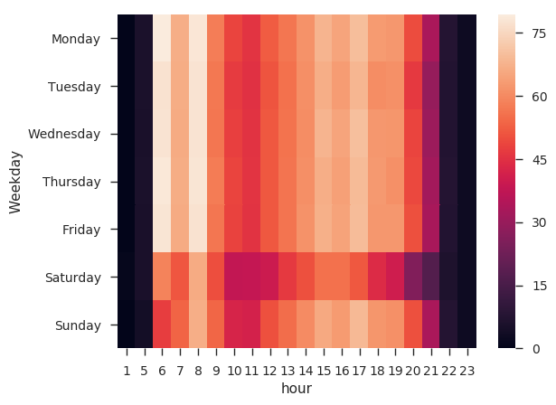

```python
plt.figure()
sns.heatmap(weekday_counts)
```

That's....ok. But still needs a little work.

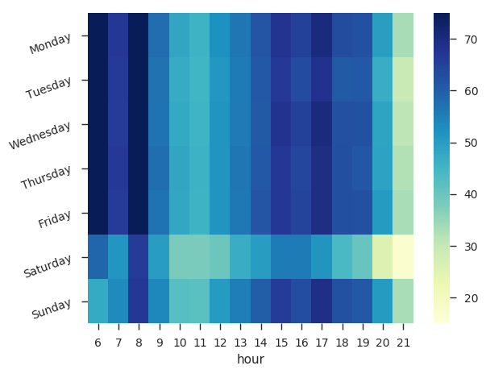

```python
plt.figure()
data2 = weekday_counts.drop([1, 5, 22, 23], axis='columns')
sns.heatmap(data2, cmap='YlGnBu', vmin=15, vmax=75)
plt.yticks(rotation=20)
plt.ylabel("")
plt.tight_layout()
```

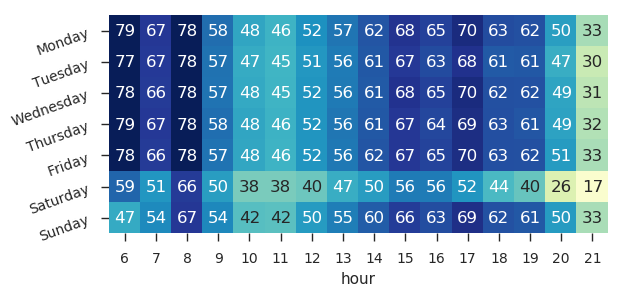

```python
plt.figure()
data2 = weekday_counts.drop([1, 5, 22, 23], axis='columns')
sns.heatmap(data2, cmap='YlGnBu', vmin=15, vmax=75, annot=True, square=True, cbar=False)
plt.yticks(rotation=20)
plt.ylabel("")
plt.tight_layout()
```

## Clustermap - Heatmap+Dendrogram

Let's see if we can cluster the days based on how they deviate from the average # of flights in the day

```python
# Get an idea of how every day deviates from the average number of flights in that day of the week
counts = flights.groupby(['Weekday', 'hour', 'day', 'month']).size().reset_index()
counts['avg'] = [weekday_counts.loc[weekday, hour] for weekday, hour in zip(counts.Weekday, counts.hour)]
counts['deviation'] = counts[0] - counts['avg']
counts['date'] = ["{}/{}".format(month, day) for month, day in zip(counts.month, counts.day)]
counts.head()
```

|  | Weekday | hour | day | month | 0 | avg | deviation | date |
| --- | --- | --- | --- | --- | --- | --- | --- | --- |
| 0 | Friday | 5 | 1 | 2 | 5 | 5.538462 | -0.538462 | 2/1 |
| 1 | Friday | 5 | 1 | 3 | 6 | 5.538462 | 0.461538 | 3/1 |
| 2 | Friday | 5 | 1 | 11 | 4 | 5.538462 | -1.538462 | 11/1 |
| 3 | Friday | 5 | 2 | 8 | 7 | 5.538462 | 1.461538 | 8/2 |
| 4 | Friday | 5 | 3 | 5 | 5 | 5.538462 | -0.538462 | 5/3 |

```python
data = counts.pivot(index='date', columns='hour', values='deviation').fillna(0)
data.head()
```

| hour date | 1 | 5 | 6 | 7 | 8 | 9 | 10 | 11 | 12 | 13 | 14 | 15 | 16 | 17 | 18 | 19 | 20 | 21 | 22 | 23 |
| --- | --- | --- | --- | --- | --- | --- | --- | --- | --- | --- | --- | --- | --- | --- | --- | --- | --- | --- | --- | --- |
| 1/1 | 0.0 | 0.396226 | -25.490566 | -17.528302 | -19.735849 | -0.962264 | -8.150943 | -8.056604 | 4.811321 | -1.660377 | -13.018868 | 0.264151 | 1.528302 | -1.433962 | -5.566038 | -11.169811 | -4.660377 | -2.735849 | 3.698113 | 0.113208 |
| 1/10 | 0.0 | -0.634615 | -2.730769 | 0.307692 | -1.942308 | -1.519231 | -5.461538 | -0.711538 | -1.634615 | -6.403846 | -7.057692 | 0.076923 | 3.980769 | -1.423077 | 1.230769 | -5.230769 | -3.076923 | -0.153846 | -0.480769 | -0.884615 |
| 1/11 | 0.0 | -0.538462 | -2.057692 | 0.903846 | -1.519231 | 0.250000 | -4.269231 | -2.519231 | -2.653846 | -5.230769 | -6.576923 | -0.019231 | 3.173077 | -3.538462 | 1.403846 | -3.480769 | -7.557692 | -2.057692 | -0.230769 | -0.942308 |
| 1/12 | 0.0 | -0.326923 | -1.884615 | -7.442308 | 3.807692 | -2.961538 | -9.134615 | -3.192308 | -1.730769 | -1.730769 | -7.288462 | -4.615385 | 2.307692 | -3.634615 | -4.000000 | -9.461538 | -4.807692 | 1.788462 | 0.596154 | -0.884615 |
| 1/13 | 0.0 | -0.250000 | -6.384615 | -11.538462 | 0.134615 | -7.884615 | -3.211538 | -3.865385 | -3.442308 | -6.211538 | -5.230769 | -1.865385 | 3.961538 | -4.000000 | 0.692308 | -3.134615 | -7.480769 | -2.269231 | -0.538462 | -0.961538 |

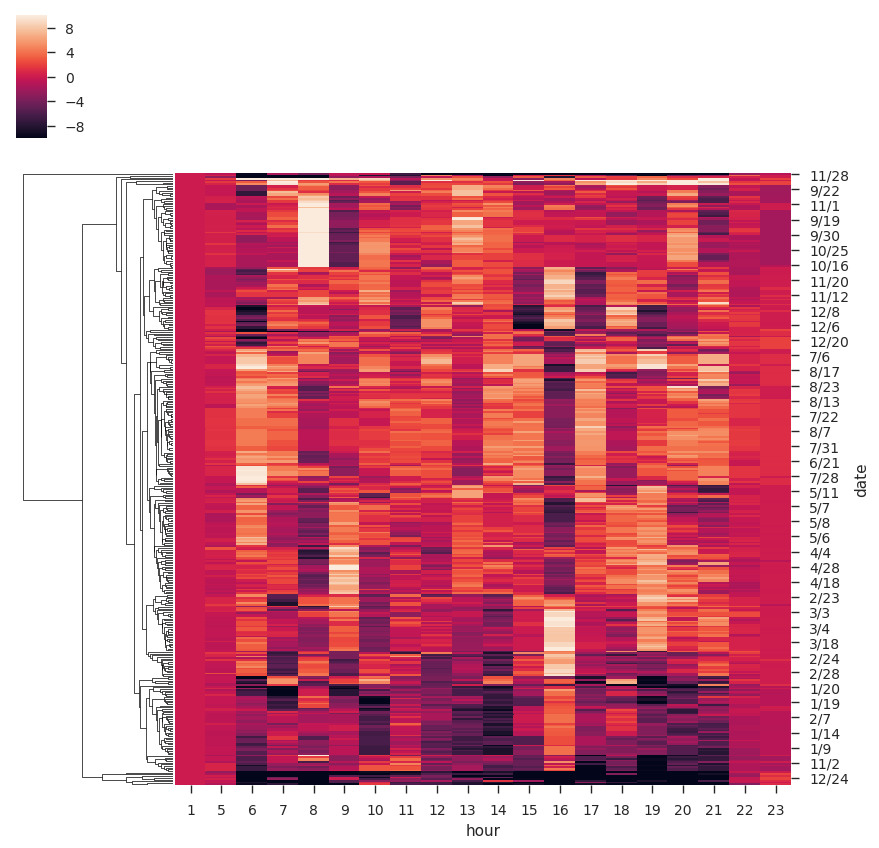

```python
cm = sns.clustermap(data, col_cluster=False, vmin=-10, vmax=10)
plt.sca(cm.ax_heatmap) # More on this in a minute
plt.yticks(rotation=0);
```

# Advanced Matplotlib

## Pyplot vs Objects

There are two ways to interact with Matplotlib plots

When we use `pyplot.plot` (abbreviated as plt.plot) to plot a picture, we're using the pyplot state machine.

This was developed to give a MATLAB-like interface to the plotting system in matplotlib.

`plt.plot` creates a plot using the **current axes** in the **current figure**.

We could also call methods on these Figures and Axes directly.

### Figures and Axes

The image below is a single Figure object, with multiple Axes.

[figure not shown]

When we call `plt.plot`, it's acually calling the `plot` method of the current Axes object.

*Snippet from the matplotlib.pyplot source on Github*

[figure not shown]

Focusing on the red-underlined parts, you can see the function really does two things.

1. Get the **current axes** by calling gca()
2. Calls ax.plot(...) on that axes and passes the arguments through.

*The rest has to do with the 'hold' state which determines if new plots are added to a figure or replace the currentplot*

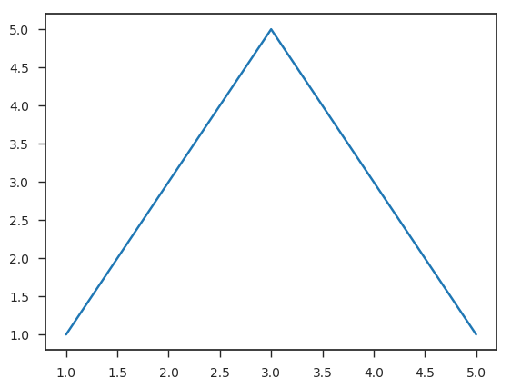

```python
plt.figure()
ax = plt.gca() # 'gca - Get Current Axes'
ax.plot([1, 2, 3, 4, 5], [1, 3, 5, 3, 1])
```

```python
fig = plt.gcf() # gcf - 'Get Current Figure'
fig.__repr__()
```

```
'<matplotlib.figure.Figure object at 0x7ff830e78048>'
```

The Axes and Figure objects provide us with an endpoint to access/modify various aspects of a plot

[figure not shown]

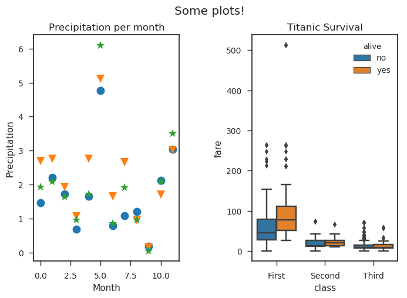

```python
fig = plt.figure(figsize=(8, 5)) # Create a new figure
ax1 = plt.subplot(1, 2, 1) # Create a subplot (returns an axes)
ax2 = plt.subplot(1, 2, 2) # Create the other subplot (returns an axes)

sns.boxplot(x='class', y='fare', hue='alive', data=titanic, ax=ax2) # Create our titanic plot, tell seaborn to use axes 2

ax1.plot(lga_precip, 'o', markersize=10)
ax1.plot(ewr_precip, 'v', markersize=10)
ax1.plot(jfk_precip, '*', markersize=10)

ax1.set_xlabel("Month") # same as plt.xlabel
ax1.set_ylabel("Precipitation") # same as plt.ylabel
ax1.set_title("Precipitation per month")

ax2.set_title("Titanic Survival")

fig.suptitle("Some plots!")

fig.subplots_adjust(wspace=.5)
```

This gives us a way to modify the plots that seaborn creates

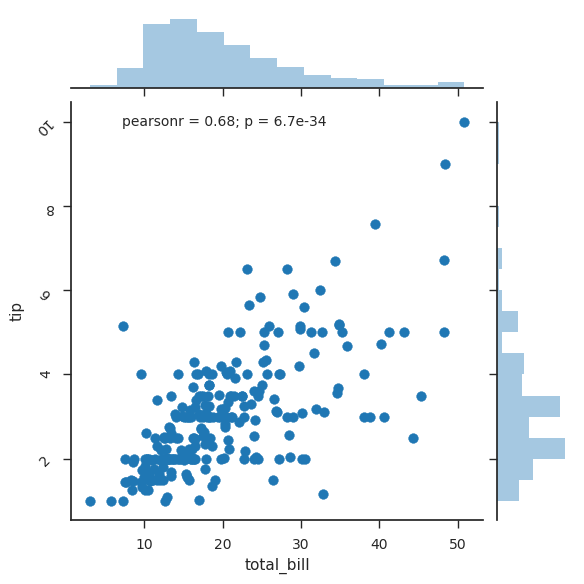

```python
jp = sns.jointplot(x='total_bill', y='tip', data=tips)
ax = jp.ax_joint # jointplot has 3 axes.  The main one is in this variable

rot = 0
for tick in ax.get_yticklabels(): # Rotate the Y tick labels
    tick.set_rotation(rot)
    rot += 45
```

## Gridspec for more complicated figure layouts

So far we just showed subplots using multiple axes that evenly divided the plot area.

If you wanted to make a more complicated layout (like what Seaborn does in jointplot above) you can use GridSpec

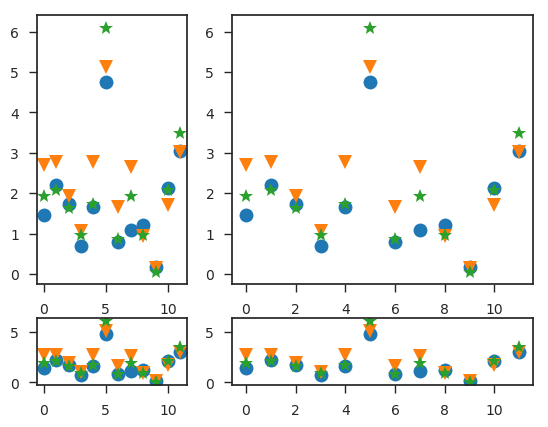

```python
from matplotlib import gridspec
plt.figure()
gs = gridspec.GridSpec(2, 2,
                       width_ratios=[1,2],
                       height_ratios=[4,1]
                       )

ax1 = plt.subplot(gs[0])
ax2 = plt.subplot(gs[1], sharey=ax1)
ax3 = plt.subplot(gs[2], sharex=ax1)
ax4 = plt.subplot(gs[3], sharex=ax2, sharey=ax3)

for ax in [ax1, ax2, ax3, ax4]:
    ax.plot(lga_precip, 'o', markersize=10)
    ax.plot(ewr_precip, 'v', markersize=10)
    ax.plot(jfk_precip, '*', markersize=10)
```

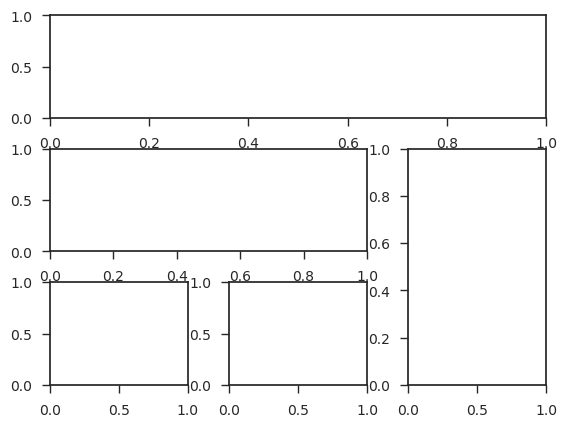

```python
# Or even crazier layouts

plt.figure()
gs = gridspec.GridSpec(3, 3)

ax1 = plt.subplot(gs[0, :])   # Use row 1, all columns
ax2 = plt.subplot(gs[1,:-1])  # Use row 2, all columns but the last one
ax3 = plt.subplot(gs[1:, -1]) # Use row 2&3, only the last column
ax4 = plt.subplot(gs[-1,0])   # Use the last row, first column
ax5 = plt.subplot(gs[-1,-2])  # Use the last row, second column

plt.subplots_adjust(wspace=.3, hspace=.3)
```

# Other plotting tools

- [Plotly](https://plot.ly/python/) (Interactive HTML/JS plots)
- [Bokeh](http://bokeh.pydata.org/en/latest/docs/gallery/les_mis.html) (More interactive HTML/JS plots)
- ggpy (ggplot-style plotting in Python)

# Closing Remarks

Whew, we covered a whole lot here!

I wouldn't expect anyone to be an expert in these tools after just one lesson, but hopefully this has given you an idea on the *kinds* of tasks where these tools are used, and how they can help you analyze data.